# CNS AP-axis VAE model

We use genes that were found to be differentially expressed and aim to understand how different groups of genes responded to PRC2 knockout.

We do this by using a variational autoencoder (VAE).

Our VAE model uses a three layer network, and as input data, takes in the normalised expression matrix including the wild type and response to Eed-cKO.

### Sections:

#### Part 1: VAE setup

```
1) Function setup
2) Read in processed dataframe and organise this
3) Build VAE model
```

#### Part 2: VAE as a ranking method

```
4) Setup data for visualisations
5) Quantify separability of latent space
6) Save VAE ranks to csv to run GSEA in R
```

#### Part 3: VAE to identify coordinating groups of genes

```
6) Build gene groups using VAE latent space
7) Save gene groups for ORA in R
8) Run motif anlaysis using FIMO on gene groups
9) Inspecting the groups in context of chromHMM annotations
10) Inspect groups in terms of annotations for Epi paper
```

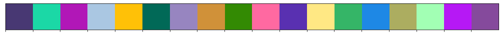

```python
"""
--------------------------------------------------------
                     Imports
--------------------------------------------------------
"""

import os, sys
import matplotlib.pyplot as plt
import seaborn as sns
import pandas as pd
import numpy as np
from sklearn.preprocessing import MinMaxScaler
from matplotlib_venn import venn3
from sklearn.decomposition import PCA
from scipy import stats
from sciviso import *
from sciutil import SciUtil
from scivae import Vis as VVis
import string
u = SciUtil()

module_path = os.path.abspath(os.path.join(''))
sys.path.append(module_path)


"""
--------------------------------------------------------
                     Global variables
--------------------------------------------------------
"""
date = '20210217'

gene_id = 'entrezgene_id'
gene_name = 'external_gene_name'

sci_colour = ['#483873', '#1BD8A6', '#B117B7', '#AAC7E2', '#FFC107', '#016957', '#9785C0',
             '#D09139', '#338A03', '#FF69A1', '#5930B1', '#FFE884', '#35B567', '#1E88E5',
             '#ACAD60', '#A2FFB4', '#B618F5', '#854A9C']

hist_colour = '#483873'

e11_colour = '#BEC0C2'
e13_colour = '#A7A9AC'
e15_colour = '#7D7E81'
e18_colour = '#58595B'

fb_colour = '#ffbf80'
mb_colour = '#ff8c1a'
hb_colour = '#b35900'
sc_colour = '#663300'
fb_color = '#ffbf80'
mb_color = '#ff8c1a'
hb_color = '#b35900'
sc_color = '#663300'

h3k36me3_colour = '#CEF471'
h3k27me3_colour = '#9F71F4'
h3k4me3_colour = '#9F00FA'
h3k4me2_colour = '#5930B1'
h3k4me1_colour = '#FFE884'
h3k27ac_colour = '#35B567'
h3k9me3_colour = '#1E88E5'
h3k9ac_colour = '#A2FFB4'

wt_colour = '#AADFF1'
ko_colour = '#A53736'

sci_colour = ['#483873', '#1BD8A6', '#B117B7', '#AAC7E2', '#FFC107', '#016957', '#9785C0',
             '#D09139', '#338A03', '#FF69A1', '#5930B1', '#FFE884', '#35B567', '#1E88E5',
             '#ACAD60', '#A2FFB4', '#B618F5', '#854A9C']
sns.palplot(sci_colour)
sns.color_palette(sci_colour)

project_name = '3_node_consistent_genes'

data_dir = '../../data/'
r_dir = f'{data_dir}results/deseq2/'
fig_dir = f'../../figures/{project_name}/vae/'
output_dir = f'{data_dir}results/{project_name}/vae/'
input_dir = f'{data_dir}results/prelim/'
rna_dir = f'{input_dir}feature-counts_04052020/'
supp_dir = f'{data_dir}input/supps/'
logging_dir = 'logging/'
ora_dir = '../../data/results/3_node_consistent_genes/functional/'

grey = '#bdbdbd'
hist_cmap = 'Greens'
rna_cmap = 'Purples'
div_cmap = 'seismic'

experiment_name = project_name
from_saved = True  # Load from a saved VAE
```

## 1) Function setup

Here we just initialise the functions that will be used in the notebook.

```python
"""
--------------------------------------------------------
                     Colour/style getters
--------------------------------------------------------
"""
def get_time_colour(c):
    if '11' in c or '10' in c:
        return e11_colour
    elif '13' in c or '12' in c:
        return e13_colour
    elif '15' in c or '14' in c:
        return e15_colour
    elif '18' in c or '16' in c:
        return e18_colour
    return '#FFFFFF'

def get_tissue_colour(c):
    if 'sc' in c or 'spinal' in c:
        return sc_colour
    elif 'hb' in c or 'hindbrain' in c:
        return hb_colour
    elif 'fb' in c or 'forebrain' in c:
        return fb_colour
    elif 'mb' in c or 'midbrain' in c:
        return mb_colour
    return '#FFFFFF'

def get_cond_colour(c):
    if 'ko' in c:
        return ko_colour
    elif 'wt' in c:
        return wt_colour
    return '#FFFFFF'

def get_mark_colour(c):
    if '36me3' in c:
        return h3k36me3_colour
    elif '27me3' in c:
        return h3k27me3_colour
    elif 'K4me3' in c:
        return h3k4me3_colour
    elif 'K4me2' in c:
        return h3k4me2_colour
    elif 'K4me1' in c:
        return h3k4me1_colour
    elif '27ac' in c:
        return h3k27ac_colour
    elif 'K9me3' in c:
        return h3k9me3_colour
    elif 'K9ac' in c:
        return h3k9ac_colour
    return '#FFFFFF'

"""
--------------------------------------------------------
                     Plotting
--------------------------------------------------------
"""
def pplot():
    return

def cplot():
    return

def save_fig(title):
    plt.savefig(f'{fig_dir}{title.replace(" ", "-")}_{experiment_name}_{date}.svg')

"""
--------------------------------------------------------
                     Heatmap and vis function
--------------------------------------------------------
"""
def plot_gene_heatmap(df, fb_genes, mb_genes, hb_genes, sc_genes,
                      input_cols, vae_data, vae, gene_name, mark, method='input',
                      title="", merge_reps=False, input_col_ids=None, cmap='', genes=None,
                      values=None, v_min=None, v_max=None):
    brain_genes = []
    colours = []
    gene_idxs = []
    genes = genes if genes is not None else df[gene_name].values
    for g1 in fb_genes:
        for i, g2 in enumerate(genes):
            if g1 == g2:
                brain_genes.append(g1)
                colours.append(fb_colour)
                gene_idxs.append(i)
                break
    for g1 in mb_genes:
        for i, g2 in enumerate(genes):
            if g1 == g2:
                brain_genes.append(g1)
                colours.append(mb_colour)
                gene_idxs.append(i)
                break
            i += 1
    for g1 in hb_genes:
        for i, g2 in enumerate(genes):
            if g1 == g2:
                brain_genes.append(g1)
                colours.append(hb_colour)
                gene_idxs.append(i)
                break

    for g1 in sc_genes:
        for i, g2 in enumerate(genes):
            if g1 == g2:
                brain_genes.append(g1)
                colours.append(sc_colour)
                gene_idxs.append(i)
                break
    heatmap_df = pd.DataFrame()
    heatmap_df[gene_name] = brain_genes

    if method == 'decoding':
        deocded = vae.decoder.predict(vae_data)
        deocded = scaler.fit_transform(deocded)
        cols_idxs = []
        for i, c in enumerate(df.columns):
            if c in input_cols:
                cols_idxs.append(i)

        val_df = pd.DataFrame(deocded[gene_idxs])
        vals = val_df[cols_idxs].values
    elif method == 'input':
        vals = df[input_cols].values[gene_idxs]
    else:
        vals = vae_data[gene_idxs]
    vals = values[gene_idxs] if values is not None else vals

    cols = []
    for i, c in enumerate(input_cols):
        if input_col_ids is not None:
            if i in input_col_ids:
                heatmap_df[c] = np.nan_to_num(vals[:,i])
                cols.append(c)
        else:
            heatmap_df[c] = np.nan_to_num(vals[:,i])
            cols.append(c)
    heatmap_cols = cols

    cols = []
    col_colours = []
    cond_colours = []
    tissue_colours = []
    time_colours = []
    for c in heatmap_df.columns:
        if 'wt' in c or 'ko' in c:
            cols.append(c)
            time_colours.append(get_time_colour(c))
            tissue_colours.append(get_tissue_colour(c))
            cond_colours.append(get_cond_colour(c))
        if mark in c and hist_metric in c:
            time_colours.append(get_time_colour(c))
            tissue_colours.append(get_tissue_colour(c))
            cond_colours.append('white')
            cols.append(c)
        elif 'log2' in c:
            time_colours.append(get_time_colour(c))
            tissue_colours.append(get_tissue_colour(c))
            cond_colours.append(get_mark_colour(c))
            cols.append(c)
    col_colours = [cond_colours, tissue_colours, time_colours]

    # Now plot the rnaseq response as a heatmap
    vmin = None
    vmax = None
    if cmap == hist_cmap or cmap == rna_cmap:
        vmin = 0
        vmax = 10
    elif cmap == div_cmap:
        vmin = -3
        vmax = 3
    if v_min != None:
        vmin = v_min
    if v_max != None:
        vmax = v_max
    heatmap = Heatmap(heatmap_df, heatmap_cols, gene_name,
                      title=title, cluster_cols=False, cluster_rows=False, vmin=vmin, vmax=vmax,
                      figsize=(3, 5),
                      cmap=cmap)
    heatmap.cmap = cmap
    heatmap.plot()
    pplot()
    plt.title(title)
    save_fig(title)
    plt.show()
```

## 2) Read in processed dataframe

Here we import the results from running the AP-axis dataset generation script.

This used the output from differential analysis and also annotated histone marks to genes.

We merge replicates to make the visualisations nicer.

```python
df_all = pd.read_csv(f'{input_dir}df-all_epi-2500_20210124.csv')
df_training = pd.read_csv(f'{input_dir}df-consistent_epi-2500_20210124.csv')
df_sig = pd.read_csv(f'{input_dir}df-significant_epi-2500_20210124.csv')

"""
--------------------------------------------------------
                    Merge replicates for vis
--------------------------------------------------------
"""

# Smooth out the columns in the data frame i.e. for the clones we only put in the mean of the two replicates
u.dp(['Merging consistently affected gene replicates'])
cols_to_merge = [c for c in df_training.columns if 'wt' in c or 'ko' in c]
i = 0
while(i < len(cols_to_merge)):
    df_training[f'{cols_to_merge[i][:-1]}_merged-rep'] = 0.5 * (df_training[cols_to_merge[i]].values +
                                                                df_training[cols_to_merge[i + 1]].values)
    print("merged", cols_to_merge[i], cols_to_merge[i + 1])
    i += 2

"""
--------------------------------------------------------
                     Merge sig. Dataset
--------------------------------------------------------
"""
u.dp(['Merging sig. affected gene replicates'])
cols_to_merge = [c for c in df_sig.columns if 'wt' in c or 'ko' in c]
i = 0
while(i < len(cols_to_merge)):
    df_sig[f'{cols_to_merge[i][:-1]}_merged-rep'] = 0.5 * (df_sig[cols_to_merge[i]].values +
                                                                df_sig[cols_to_merge[i + 1]].values)
    print("merged", cols_to_merge[i], cols_to_merge[i + 1])
    i += 2

"""
--------------------------------------------------------
                     Merge all dataset
--------------------------------------------------------
"""
u.dp(['Merging whole dataset'])
cols_to_merge = [c for c in df_all.columns if 'wt' in c or 'ko' in c]
i = 0
while(i < len(cols_to_merge)):
    df_all[f'{cols_to_merge[i][:-1]}_merged-rep'] = 0.5 * (df_all[cols_to_merge[i]].values +
                                                                df_all[cols_to_merge[i + 1]].values)
    print("merged", cols_to_merge[i], cols_to_merge[i + 1])
    i += 2
```

```
--------------------------------------------------------------------------------
                 Merging consistently affected gene replicates
--------------------------------------------------------------------------------
merged wt11fb1 wt11fb2
merged wt13fb1 wt13fb2
merged wt15fb1 wt15fb2
merged wt18fb1 wt18fb2
merged wt11mb1 wt11mb2
merged wt13mb1 wt13mb2
merged wt15mb1 wt15mb2
merged wt18mb1 wt18mb2
merged wt11hb1 wt11hb2
merged wt13hb1 wt13hb2
merged wt15hb1 wt15hb2
merged wt18hb1 wt18hb2
merged wt11sc1 wt11sc2
merged wt13sc1 wt13sc2
merged wt15sc1 wt15sc2
merged wt18sc1 wt18sc2
merged ko11fb1 ko11fb2
merged ko13fb1 ko13fb2
merged ko15fb1 ko15fb2
merged ko18fb1 ko18fb2
merged ko11mb1 ko11mb2
merged ko13mb1 ko13mb2
merged ko15mb1 ko15mb2
merged ko18mb1 ko18mb2
merged ko11hb1 ko11hb2
merged ko13hb1 ko13hb2
merged ko15hb1 ko15hb2
merged ko18hb1 ko18hb2
merged ko11sc1 ko11sc2
merged ko13sc1 ko13sc2
merged ko15sc1 ko15sc2
merged ko18sc1 ko18sc2
--------------------------------------------------------------------------------
                     Merging sig. affected gene replicates
--------------------------------------------------------------------------------
merged wt11fb1 wt11fb2
merged wt13fb1 wt13fb2
```

[output cut: 50 more lines]

```
merged ko13fb1 ko13fb2
merged ko15fb1 ko15fb2
merged ko18fb1 ko18fb2
merged ko11mb1 ko11mb2
merged ko13mb1 ko13mb2
merged ko15mb1 ko15mb2
merged ko18mb1 ko18mb2
merged ko11hb1 ko11hb2
merged ko13hb1 ko13hb2
merged ko15hb1 ko15hb2
merged ko18hb1 ko18hb2
merged ko11sc1 ko11sc2
merged ko13sc1 ko13sc2
merged ko15sc1 ko15sc2
merged ko18sc1 ko18sc2
```

```python
df_all_genes = df_all[gene_name].values
caff_genes = df_training[gene_name].values
sig_genes = df_sig[gene_name].values

gene_markers_sep = [['Emx1', 'Eomes', 'Tbr1', 'Foxg1', 'Lhx6'],
                    ['En1', 'En2', 'Lmx1a', 'Bhlhe23', 'Sall4'],
                    ['Hoxb1', 'Krox20', 'Fev', 'Hoxd3', 'Phox2b'],
                    ['Hoxd8', 'Hoxd9', 'Hoxd10', 'Hoxd11', 'Hoxd12', 'Hoxd13', 'Hoxa7', 'Hoxa9', 'Hoxa10', 'Hoxa11',
                    'Hoxa13', 'Hoxb9', 'Hoxb13',  'Hoxc8', 'Hoxc9', 'Hoxc10', 'Hoxc11', 'Hoxc12', 'Hoxc13'],
                    ['Ccna1', 'Ccna2', 'Ccnd1', 'Ccnd2', 'Ccnd3', 'Ccne1', 'Ccne2', 'Cdc25a',
                    'Cdc25b', 'Cdc25c', 'E2f1', 'E2f2', 'E2f3', 'Mcm10', 'Mcm5', 'Mcm3', 'Mcm2', 'Cip2a'],
                    ['Cdkn1a', 'Cdkn1b', 'Cdkn1c', 'Cdkn2a', 'Cdkn2b', 'Cdkn2c', 'Cdkn2d'],
                    ['Sox2', 'Sox1', 'Sox3', 'Hes1', 'Hes5'],
                    ['Snap25', 'Syt1', 'Slc32a1','Slc17a6', 'Syn1'],
                    ['Cspg4', 'Aqp4', 'Slc6a11', 'Olig1', 'Igfbp3']]
u.dp(['Not affected markers'])
for gl in gene_markers_sep:
    for g in gl:
        if g in df_all_genes and g not in caff_genes and g not in sig_genes:
            print(g)

for gl in gene_markers_sep:
    for g in gl:
        if g in sig_genes and g not in caff_genes:
            u.dp([g])
        elif g in caff_genes:
            u.err_p([g])
```

```
--------------------------------------------------------------------------------
                             Not affected markers
--------------------------------------------------------------------------------
Hoxd12
--------------------------------------------------------------------------------
                                     Emx1
--------------------------------------------------------------------------------
--------------------------------------------------------------------------------
                                     Eomes
--------------------------------------------------------------------------------
--------------------------------------------------------------------------------
                                     Tbr1
--------------------------------------------------------------------------------
--------------------------------------------------------------------------------
                                     Foxg1
--------------------------------------------------------------------------------
--------------------------------------------------------------------------------
                                     Lhx6
--------------------------------------------------------------------------------
--------------------------------------------------------------------------------
                                      En1
--------------------------------------------------------------------------------
--------------------------------------------------------------------------------
                                      En2
--------------------------------------------------------------------------------
--------------------------------------------------------------------------------
                                     Lmx1a
--------------------------------------------------------------------------------
--------------------------------------------------------------------------------
                                    Bhlhe23
--------------------------------------------------------------------------------
--------------------------------------------------------------------------------
                                     Sall4
--------------------------------------------------------------------------------
--------------------------------------------------------------------------------
                                     Hoxb1
--------------------------------------------------------------------------------
--------------------------------------------------------------------------------
                                      Fev
--------------------------------------------------------------------------------
```

[output cut: 165 more lines]

```
--------------------------------------------------------------------------------
                                     Cspg4
--------------------------------------------------------------------------------
--------------------------------------------------------------------------------
                                     Aqp4
--------------------------------------------------------------------------------
--------------------------------------------------------------------------------
                                    Slc6a11
--------------------------------------------------------------------------------
--------------------------------------------------------------------------------
                                     Olig1
--------------------------------------------------------------------------------
--------------------------------------------------------------------------------
                                    Igfbp3
--------------------------------------------------------------------------------
```

## 3) Build VAE model

Since the VAEs are stochastic rather than deterministic we want to create our clusters based on a number of iterations. We also are interested in how much the genes differ in various latent spaces.

```python
from scivae import VAE

hist_metric = 'signal'
labels = df_training[gene_name].values


# -----------------------------------------------------------------------------------
#                         Set the input data space
# -----------------------------------------------------------------------------------
def get_input_data(df: pd.DataFrame, label_col: str):
    scaler = MinMaxScaler(copy=True)
    """ Here we define the data for the VAE we choose to log2 the signal """
    cols_bin = []
    tmp_df = pd.DataFrame()
    non_nan_df = df.copy()
    non_nan_df = non_nan_df.fillna(0)
    for c in df.columns:
        if 'H3K27me3' in c and 'signal' in c and 'brain' in c:
            v = np.log2(non_nan_df[c].values + 1)
            nn_min = np.nanmin(v)
            nn_max = np.nanmax(v)
            tmp_df[f'{c}_log2'] = (v-nn_min) / (nn_max - nn_min)
            cols_bin.append(f'{c}_log2')
        elif ('merged-rep' not in c) and ('log2FoldChange' in c or 'wt' in c or 'ko' in c):
            cols_bin.append(c)
            v = non_nan_df[c].values
            nn_min = np.nanmin(v)
            nn_max = np.nanmax(v)
            tmp_df[c] = (v-nn_min) / (nn_max - nn_min)
    vae_values = tmp_df[cols_bin].values
    vae_values = np.nan_to_num(vae_values)
    tmp_df[label_col] = df[label_col].values
    return vae_values, tmp_df, df[label_col].values
```

```python
# # -----------------------------------------------------------------------------------
# #                         Run a test to work out the best number of nodes
# # -----------------------------------------------------------------------------------
# vae_input_values, df_input, labels = get_input_data(df_training, gene_name)
# tsts = [1, 2, 3, 4, 6, 8, 16, 24]
# for i in tsts:
#     for j in range(0, 5):
#         config = {'loss': {'loss_type': 'mse', 'distance_metric': 'mmd', 'mmd_weight': 2.0},
#                   'encoding': {'layers': [{'num_nodes': 64, 'activation_fn': 'selu'},
#                                           {'num_nodes': 32, 'activation_fn': 'relu'}]},
#                   'decoding': {'layers': [{'num_nodes': 32, 'activation_fn': 'relu'},
#                                           {'num_nodes': 64, 'activation_fn': 'selu'}]},
#                   'latent': {'num_nodes': i}, 'optimiser': {'params': {}, 'name': 'adam'}}

#         vae_mse = VAE(vae_input_values, vae_input_values, labels, config, f'vae_num-nodes_{i}_rep_{j}')
#         vae_mse.encode('default', epochs=100, batch_size=50,
#                        logging_dir=logging_dir, logfile=f'run_num-nodes_{i}_rep_{j}.csv')

# # -----------------------------------------------------------------------------------
# #                         Plot results
# # -----------------------------------------------------------------------------------

# # Read in each of the csv's and then add a line for each one
# tsts = [1, 2, 3, 4, 6, 8, 16, 24]
# fig, ax = plt.subplots()
# labels = []
# for i, t in enumerate(tsts):
#     c = sci_colour[i]
#     print(c, i)
#     for j in range(0, 5):
#         d = pd.read_csv(f'{logging_dir}run_num-nodes_{t}_rep_{j}.csv')
#         print(f'{logging_dir}run_num-nodes_{t}_rep_{j}.csv')
#         ax.plot(d['epoch'].values, d['loss'].values, c=c, alpha=0.5)
#         label=f'{t} node(s)'
#         if label not in labels:
#             ax.plot(d['epoch'].values, d['val_loss'].values, c=c, alpha=0.8, label=label)
#             labels.append(label)
#         else:
#             ax.plot(d['epoch'].values, d['val_loss'].values, c=c, alpha=0.8)

# ax.legend(loc='center left', bbox_to_anchor=(1, 0.5))
# axes = plt.gca()
# axes.set_ylim([0, 5])
# save_fig(f'node_num')
# plt.show()
```

```python
from_saved
```

```
True
```

```python
# -----------------------------------------------------------------------------------
#                         Based on the above, set the number of nodes
#                         1) Build non-linear VAE
#                         2) Build linear VAE
# -----------------------------------------------------------------------------------
num_nodes = 3
vae_input_values, df_input, labels = get_input_data(df_training, gene_name)

config = {'loss': {'loss_type': 'mse', 'distance_metric': 'mmd', 'mmd_weight': 1.0,
                   'mmcd_method': 'k'},
                  'encoding': {'layers': [{'num_nodes': 64, 'activation_fn': 'selu'},
                                          {'num_nodes': 32, 'activation_fn': 'relu'}
                                          ]},
                  'decoding': {'layers': [
                                          {'num_nodes': 32, 'activation_fn': 'relu'},
                                          {'num_nodes': 64, 'activation_fn': 'selu'}]},
                  'latent': {'num_nodes': num_nodes}, 'optimiser': {'params': {}, 'name': 'adam'}}

vae_mse = VAE(vae_input_values, vae_input_values, labels, config, f'final')
if not from_saved:
    vae_mse.encode('default', epochs=250, batch_size=50,
                   logging_dir="final_vae_logs", logfile=f'final.csv')
    vae_mse.save() # save the VAE
    vae_mse.u.dp(["Saved VAE to current directory."])
else:
    vae_mse.u.dp(["Trying to load saved VAE..."])
    vae_mse.load()
    vae_mse.u.dp(["Loaded saved VAE :) "])

df = df_training.copy()

# Encode the values using the VAE
scaler = MinMaxScaler(copy=True)
scaled_vals = scaler.fit_transform(vae_input_values)
vae_data = vae_mse.encode_new_data(scaled_vals)
```

```
None
--------------------------------------------------------------------------------
                          Trying to load saved VAE...
--------------------------------------------------------------------------------
Model: "encoder"
__________________________________________________________________________________________________
Layer (type)                    Output Shape         Param #     Connected to
==================================================================================================
default_input (InputLayer)      [(None, 97)]         0
__________________________________________________________________________________________________
dense (Dense)                   (None, 64)           6272        default_input[0][0]
__________________________________________________________________________________________________
dense_1 (Dense)                 (None, 32)           2080        dense[0][0]
__________________________________________________________________________________________________
z_mean (Dense)                  (None, 3)            99          dense_1[0][0]
__________________________________________________________________________________________________
z_log_sigma (Dense)             (None, 3)            99          dense_1[0][0]
__________________________________________________________________________________________________
z (Lambda)                      (None, 3)            0           z_mean[0][0]
                                                                 z_log_sigma[0][0]
==================================================================================================
Total params: 8,550
Trainable params: 8,550
Non-trainable params: 0
__________________________________________________________________________________________________
Model: "decoder"
_________________________________________________________________
Layer (type)                 Output Shape              Param #
=================================================================
z_sampling (InputLayer)      [(None, 3)]               0
_________________________________________________________________
dense_2 (Dense)              (None, 32)                128
_________________________________________________________________
dense_3 (Dense)              (None, 64)                2112
_________________________________________________________________
dense_4 (Dense)              (None, 97)                6305
=================================================================
Total params: 8,545
Trainable params: 8,545
Non-trainable params: 0
```

[output cut: 177 more lines]

```
tf.__operators__.add_1 (TFOpLam (None,)              0           tf.math.reduce_sum[0][0]
                                                                 tf.math.multiply_1[0][0]
__________________________________________________________________________________________________
tf.math.reduce_mean_6 (TFOpLamb ()                   0           tf.__operators__.add_1[0][0]
__________________________________________________________________________________________________
add_loss (AddLoss)              ()                   0           tf.math.reduce_mean_6[0][0]
==================================================================================================
Total params: 17,095
Trainable params: 17,095
Non-trainable params: 0
__________________________________________________________________________________________________
None
--------------------------------------------------------------------------------
                             Loaded saved VAE :)
--------------------------------------------------------------------------------
```

## 4) Setup data for visualisations

Here we setup the data and summarise key features, for example calcualting the median values.

We do this so we can easily access these later.

```python
# -----------------------------------------------------------------------------------
#                         Data setup for Vis
# -----------------------------------------------------------------------------------

hist_metric = 'signal'
input_cols = list(df_input.columns)


def get_median(df, mark, time="", tissue="brain"):
    cols = []
    for c in df.columns:
        if tissue in c and mark in c and hist_metric in c and time in c and 'median' not in c:
            cols.append(c)
    # get nan median
    vals = np.nanmedian(df[cols].values, axis=1)

    return np.nan_to_num(vals)

marks = ['H3K27me3', 'H3K4me1', 'H3K4me2', 'H3K4me3', 'H3K27ac', 'H3K9me3', 'H3K36me3', 'H3K9ac']

# Get the median over all time points and all brain tissues
for m in marks:
    df[f'{m}'] = get_median(df, m, time="", tissue="brain")

times = ['10.5', '11.5', '12.5', '13.5', '14.5', '15.5', '16.5']
for m in marks:
    for e in times:
        df[f'median_brain_{e}_signal_{m}'] = get_median(df, m, time=e, tissue="brain")

tissues = ['hindbrain', 'midbrain', 'forebrain']
for m in marks:
    for e in times:
        for t in tissues:
            df[f'median_{t}_{e}_signal_{m}'] = get_median(df, m, time=e, tissue=t)


df['mean_wt'] = np.mean(df[[c for c in df.columns if 'wt' in c]].values, axis=1)
df['mean_ko'] = np.mean(df[[c for c in df.columns if 'ko' in c]].values, axis=1)
df['mean_ko-wt'] = df['mean_ko'].values - df['mean_wt'].values

# Add in the VAE columns
for v in range(0, len(vae_data[0])):
    df[f'VAE{v}'] = vae_data[:, v]

# Rename/add some columns just to make figs easier
df['Log2FC FB'] = df['log2FoldChange_fb'].values
df['Log2FC MB'] = df['log2FoldChange_mb'].values
df['Log2FC HB'] = df['log2FoldChange_hb'].values
df['Log2FC SC'] = df['log2FoldChange_sc'].values
df['Log2FC A11'] = df['log2FoldChange_a11'].values
df['Log2FC A13'] = df['log2FoldChange_a13'].values
df['Log2FC A15'] = df['log2FoldChange_a15'].values
df['Log2FC A18'] = df['log2FoldChange_a18'].values
df['Log2FC P11'] = df['log2FoldChange_p11'].values
df['Log2FC P13'] = df['log2FoldChange_p13'].values
df['Log2FC P15'] = df['log2FoldChange_p15'].values
df['Log2FC P18'] = df['log2FoldChange_p18'].values

all_cols = [
    'H3K9me3',
    'H3K4me1',
    'H3K4me2',
    'H3K4me3',
    'H3K27ac',
    'H3K36me3',
    'H3K9ac',
    'mean_wt',
    'mean_ko',
    'mean_ko-wt',
    'H3K27me3',
    'Log2FC FB',
    'Log2FC MB',
    'Log2FC HB',
    'Log2FC SC',
    'VAE0',
    'VAE1',
    'VAE2',
    'Log2FC A11',
    'Log2FC A13',
    'Log2FC A15',
    'Log2FC A18',
    'Log2FC P11',
    'Log2FC P13',
    'Log2FC P15',
    'Log2FC P18'
]
unobserved_cols = [
    'H3K9me3',
    'H3K4me1',
    'H3K4me2',
    'H3K4me3',
    'H3K27ac',
    'H3K36me3',
    'H3K9ac',
    'mean_wt',
    'mean_ko',
    'mean_ko-wt'
]

observed_cols = [
    'H3K4me1',
    'H3K4me2',
    'H3K4me3',
    'H3K27ac',
    'H3K36me3',
    'H3K27me3',
    'Log2FC FB',
    'Log2FC MB',
    'Log2FC HB',
    'Log2FC SC',
    'VAE0',
    'VAE1',
    'VAE2'
]

hist_cols = [
    'H3K9me3',
    'H3K4me1',
    'H3K4me2',
    'H3K4me3',
    'H3K27ac',
    'H3K36me3',
    'H3K27me3',
    'H3K9ac'
]

div_cols = [
    'Log2FC FB',
    'Log2FC MB',
    'Log2FC HB',
    'Log2FC SC',
    'Log2FC A11',
    'Log2FC A13',
    'Log2FC A15',
    'Log2FC A18',
    'Log2FC P11',
    'Log2FC P13',
    'Log2FC P15',
    'Log2FC P18',
]

raw_cols = [
    'mean_wt',
    'mean_ko'
]
vae_cols = observed_cols
df_unobserved = df[unobserved_cols]
df_observed = df[observed_cols]
observed_dict = {}

for c in observed_cols:
    observed_dict[c] = df_observed[c].values
unobserved_dict = {}
for c in unobserved_cols:
    unobserved_dict[c] = df_unobserved[c].values
```

## 5. Plots for Figure 1

- Figure I: The gene heatmaps for select spatial marker genes
- Figure K: The gene heatmaps for sox genes normalised to gene expression level
- Suppl. Figure with all Hox genes
- Figure J: Line plots of the larger marker gene lists

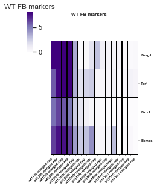

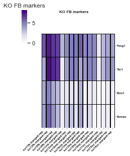

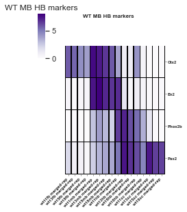

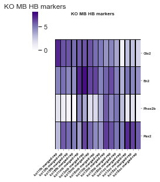

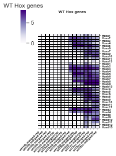

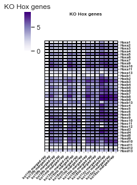

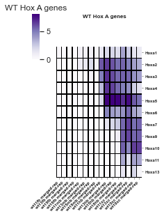

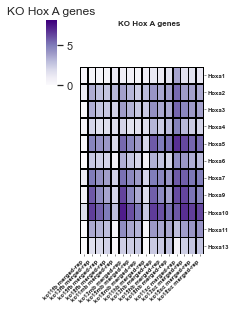

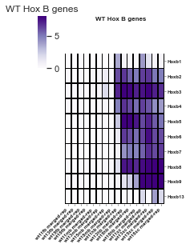

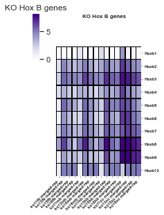

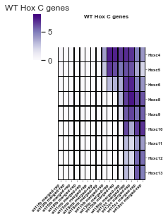

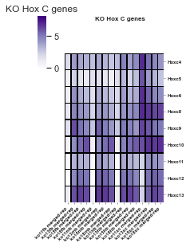

[2 more figures not shown]

```python
all_vae_data = np.copy(vae_data)
vae_data = all_vae_data[:, 0:3]
vae_vis = VVis(vae_mse, u, None)
div_cmap = 'seismic'
input_cols = [c for c in df_input.columns if c != gene_name]

merged_cols = [c for c in df.columns if "merged" in c]
# Also do the main markers
fb_genes = ['Foxg1', 'Tbr1', 'Emx1', 'Eomes']
mb_genes = ['Otx2', 'En2', 'Phox2b', 'Pax2']
hb_genes = ['Hoxd3', 'Pax2']
sc_genes = [ 'Hoxb9', 'Hoxc9', 'Hoxd9']
all_hox_genes = [
    'Hoxa1',
    'Hoxa2',
    'Hoxa3',
    'Hoxa4',
    'Hoxa5',
    'Hoxa6',
    'Hoxa7',
    'Hoxa8', # N CS
    'Hoxa9',
    'Hoxa10',
    'Hoxa11',
    'Hoxa12',  # N CS
    'Hoxa13',

    'Hoxb1',
    'Hoxb2',
    'Hoxb3',
    'Hoxb4',
    'Hoxb5',
    'Hoxb6',
    'Hoxb7',
    'Hoxb8',
    'Hoxb9',
    'Hoxb10'
    'Hoxb11',
    'Hoxb12',
    'Hoxb13',

    'Hoxc1', # N CS
    'Hoxc2', # N CS
    'Hoxc3', # N CS
    'Hoxc4',
    'Hoxc5',
    'Hoxc6',
    'Hoxc7',
    'Hoxc8',
    'Hoxc9',
    'Hoxc10',
    'Hoxc11',
    'Hoxc12',
    'Hoxc13'

    'Hoxd1', # N CS
    'Hoxd2', # N CS
    'Hoxd3',
    'Hoxd4',
    'Hoxd5', # N CS
    'Hoxd6',# N CS
    'Hoxd7',# N CS
    'Hoxd8',
    'Hoxd9',
    'Hoxd10',
    'Hoxd11',
    'Hoxd12', # N CS
    'Hoxd13'
 ]
sox_genes = ['Sox1', 'Sox2', 'Sox3']

# -----------------------------------------------------------------------------------
#                         Figure I
# -----------------------------------------------------------------------------------
wt_merged_cols = [c for c in merged_cols if 'wt' in c]
plot_gene_heatmap(df, fb_genes, [], [], [],
                  wt_merged_cols, vae_data, vae_mse,
                  gene_name, mark='', method='input', cmap=rna_cmap, title='WT FB markers',
                 v_min=0, v_max=8)
ko_merged_cols = [c for c in merged_cols if 'ko' in c]
plot_gene_heatmap(df, fb_genes, [], [], [],
                  ko_merged_cols, vae_data, vae_mse,
                  gene_name, mark='', method='input', cmap=rna_cmap, title='KO FB markers',
                 v_min=0, v_max=8)
wt_merged_cols = [c for c in merged_cols if 'wt' in c]
plot_gene_heatmap(df, [], mb_genes, [], [],
                  wt_merged_cols, vae_data, vae_mse,
                  gene_name, mark='', method='input', cmap=rna_cmap, title='WT MB HB markers',
                 v_min=0, v_max=8)
ko_merged_cols = [c for c in merged_cols if 'ko' in c]
plot_gene_heatmap(df, [], mb_genes, [], [],
                  ko_merged_cols, vae_data, vae_mse,
                  gene_name, mark='', method='input', cmap=rna_cmap, title='KO MB HB markers',
                 v_min=0, v_max=8)
# -----------------------------------------------------------------------------------
#                         Figure I. Suppl All Hoxs
# -----------------------------------------------------------------------------------
wt_merged_cols = [c for c in merged_cols if 'wt' in c]
plot_gene_heatmap(df_all, [], [], [], all_hox_genes,
                  wt_merged_cols, vae_data, vae_mse,
                  gene_name, mark='', method='input', cmap=rna_cmap, title='WT Hox genes', v_min=0, v_max=8)
ko_merged_cols = [c for c in merged_cols if 'ko' in c]
plot_gene_heatmap(df_all, [], [], [], all_hox_genes,
                  ko_merged_cols, vae_data, vae_mse,
                  gene_name, mark='', method='input', cmap=rna_cmap, title='KO Hox genes', v_min=0, v_max=8)

hox_a = [
    'Hoxa1',
    'Hoxa2',
    'Hoxa3',
    'Hoxa4',
    'Hoxa5',
    'Hoxa6',
    'Hoxa7',
    'Hoxa8', # N CS
    'Hoxa9',
    'Hoxa10',
    'Hoxa11',
    'Hoxa12',  # N CS
    'Hoxa13']
hox_b = [
    'Hoxb1',
    'Hoxb2',
    'Hoxb3',
    'Hoxb4',
    'Hoxb5',
    'Hoxb6',
    'Hoxb7',
    'Hoxb8',
    'Hoxb9',
    'Hoxb10'
    'Hoxb11',
    'Hoxb12',
    'Hoxb13']

hox_c = [
    'Hoxc1', # N CS
    'Hoxc2', # N CS
    'Hoxc3', # N CS
    'Hoxc4',
    'Hoxc5',
    'Hoxc6',
    'Hoxc7',
    'Hoxc8',
    'Hoxc9',
    'Hoxc10',
    'Hoxc11',
    'Hoxc12',
    'Hoxc13']
hox_d = [
    'Hoxd1', # N CS
    'Hoxd2', # N CS
    'Hoxd3',
    'Hoxd4',
    'Hoxd5', # N CS
    'Hoxd6',# N CS
    'Hoxd7',# N CS
    'Hoxd8',
    'Hoxd9',
    'Hoxd10',
    'Hoxd11',
    'Hoxd12', # N CS
    'Hoxd13'
 ]

wt_merged_cols = [c for c in merged_cols if 'wt' in c]
plot_gene_heatmap(df_all, [], [], [], hox_a,
                  wt_merged_cols, vae_data, vae_mse,
                  gene_name, mark='', method='input', cmap=rna_cmap, title='WT Hox A genes', v_min=0, v_max=8)
ko_merged_cols = [c for c in merged_cols if 'ko' in c]
plot_gene_heatmap(df_all, [], [], [], hox_a,
                  ko_merged_cols, vae_data, vae_mse,
                  gene_name, mark='', method='input', cmap=rna_cmap, title='KO Hox A genes', v_min=0, v_max=8)

wt_merged_cols = [c for c in merged_cols if 'wt' in c]
plot_gene_heatmap(df_all, [], [], [], hox_b,
                  wt_merged_cols, vae_data, vae_mse,
                  gene_name, mark='', method='input', cmap=rna_cmap, title='WT Hox B genes', v_min=0, v_max=8)
ko_merged_cols = [c for c in merged_cols if 'ko' in c]
plot_gene_heatmap(df_all, [], [], [], hox_b,
                  ko_merged_cols, vae_data, vae_mse,
                  gene_name, mark='', method='input', cmap=rna_cmap, title='KO Hox B genes', v_min=0, v_max=8)

wt_merged_cols = [c for c in merged_cols if 'wt' in c]
plot_gene_heatmap(df_all, [], [], [], hox_c,
                  wt_merged_cols, vae_data, vae_mse,
                  gene_name, mark='', method='input', cmap=rna_cmap, title='WT Hox C genes', v_min=0, v_max=8)
ko_merged_cols = [c for c in merged_cols if 'ko' in c]
plot_gene_heatmap(df_all, [], [], [], hox_c,
                  ko_merged_cols, vae_data, vae_mse,
                  gene_name, mark='', method='input', cmap=rna_cmap, title='KO Hox C genes', v_min=0, v_max=8)

wt_merged_cols = [c for c in merged_cols if 'wt' in c]
plot_gene_heatmap(df_all, [], [], [], hox_d,
                  wt_merged_cols, vae_data, vae_mse,
                  gene_name, mark='', method='input', cmap=rna_cmap, title='WT Hox D genes', v_min=0, v_max=8)
ko_merged_cols = [c for c in merged_cols if 'ko' in c]
plot_gene_heatmap(df_all, [], [], [], hox_d,
                  ko_merged_cols, vae_data, vae_mse,
                  gene_name, mark='', method='input', cmap=rna_cmap, title='KO Hox D genes', v_min=0, v_max=8)
```

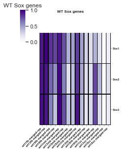

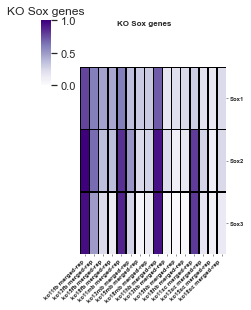

```python
# -----------------------------------------------------------------------------------
#                         Figure K
# -----------------------------------------------------------------------------------
x = df_sig[wt_merged_cols + ko_merged_cols].values #returns a numpy array
x = ((x.T - np.min(x, axis=1))/(np.max(x, axis=1) - np.min(x, axis=1))).T
df_norm = pd.DataFrame(x)
df_norm.columns = wt_merged_cols + ko_merged_cols

# Normalise Sox rows so we can see comparative difference more easily
df_norm[gene_name] = df_sig[gene_name].values
plot_gene_heatmap(df_norm, ['Sox1'], ['Sox2'], ['Sox3'], [],
                  wt_merged_cols, vae_data, vae_mse,
                  gene_name, mark='', method='input', genes=None,  cmap=rna_cmap, title='WT Sox genes',
                  v_min=0, v_max=1
                 )

ko_merged_cols = [c for c in merged_cols if 'ko' in c]
plot_gene_heatmap(df_norm, ['Sox1'], ['Sox2'], ['Sox3'], [],
                  ko_merged_cols, vae_data, vae_mse,
                  gene_name, mark='', genes=None,  method='input', cmap=rna_cmap, title='KO Sox genes',
                  v_min=0, v_max=1)
```

#### Figure 1 Line plots

```python
import statsmodels.stats.api as sms

from sklearn import linear_model
plt.rcParams['svg.fonttype'] = 'none'  # Ensure text is saved as text
plt.rcParams['figure.figsize'] = (1, 1)
sns.set(rc={'figure.figsize': (1, 1), 'font.family': 'sans-serif',
            'font.sans-serif': 'Arial', 'font.size': 6}, style='ticks')

def set_ax_params(ax):
    ax.tick_params(direction='out', length=2, width=0.5)
    ax.spines['bottom'].set_linewidth(0.5)
    ax.spines['top'].set_linewidth(0)
    ax.spines['left'].set_linewidth(0.5)
    ax.spines['right'].set_linewidth(0)
    ax.tick_params(labelsize=6)
    ax.tick_params(axis='x', which='major', pad=2.0)
    ax.tick_params(axis='y', which='major', pad=2.0)


e11_cols = [c for c in df_training if 'ko' in c and '11' in c and 'merged' in c]
e13_cols = [c for c in df_training if 'ko' in c and '13' in c and 'merged' in c]
e15_cols = [c for c in df_training if 'ko' in c and '15' in c and 'merged' in c]
e18_cols = [c for c in df_training if 'ko' in c and '18' in c and 'merged' in c]

w_e11_cols = [c for c in df_training if 'wt' in c and '11' in c and 'merged' in c]
w_e13_cols = [c for c in df_training if 'wt' in c and '13' in c and 'merged' in c]
w_e15_cols = [c for c in df_training if 'wt' in c and '15' in c and 'merged' in c]
w_e18_cols = [c for c in df_training if 'wt' in c and '18' in c and 'merged' in c]

ko_fb_cols = [c for c in df_training if 'ko' in c and 'fb' in c and 'merged' in c]
wt_fb_cols = [c for c in df_training if 'wt' in c and 'fb' in c and 'merged' in c]

def get_gis(genes, df):
    gene_idxs = []
    gene_names = []
    for i, g in enumerate(df[gene_name].values):
        if g in genes:
            gene_idxs.append(i)
            gene_names.append(g)
    return gene_idxs, gene_names

def plot_tissue_line(w_e18_cols, gene_idxs, gene_names, df_training, title='', ko_e18_cols=None):
    labels_lst = []
    c_i = 5
    wt_colour = '#5ebce5'
    fig, ax = plt.subplots()
    wt_values = []
    ko_values = []
    for i, g in enumerate(gene_names):
        labels_lst.append(f'WT {g}')
        wt_values.append(df_training[w_e18_cols].values[gene_idxs[i]])
        if ko_e18_cols:
            labels_lst.append(f'Eed-cKO {g}')
            ko_values.append(df_training[ko_e18_cols].values[gene_idxs[i]])
        c_i += 1
        if c_i == len(sci_colour):
            c_i = 0
    wt_values = np.array(wt_values)
    ko_values = np.array(ko_values)
    wt_mean = np.mean(wt_values, axis=0)
    ko_mean = np.mean(ko_values, axis=0)

    wt_yerr = np.std(wt_values, axis=0)/np.sqrt(len(wt_values[0]))
    ko_yerr = np.std(ko_values, axis=0)/np.sqrt(len(ko_values[0]))

    (_, caps, _) = ax.errorbar(['FB', 'MB', 'HB', 'SC'], wt_mean, yerr=wt_yerr,
                               fmt='o', markersize=3, capsize=5, c=wt_colour, alpha=1.0, linewidth=2.0)
    for cap in caps:
        cap.set_markeredgewidth(1)

    (_, caps, _) = ax.errorbar(['FB', 'MB', 'HB', 'SC'], ko_mean, yerr=ko_yerr, fmt='o', markersize=3, capsize=5,
                               c=ko_colour, alpha=1.0, linewidth=2.0)

    for cap in caps:
        cap.set_markeredgewidth(1)


    ax.plot(['FB', 'MB', 'HB', 'SC'], wt_mean, c=wt_colour, alpha=1.0, linewidth=1.0)
    ax.plot(['FB', 'MB', 'HB', 'SC'], ko_mean, c=ko_colour, alpha=1.0, linewidth=1.0)

    plt.title(f'{title}')
    ax.tick_params(labelsize=6)
    ax.set_ylim(0, 8)

    set_ax_params(ax)
    save_fig(f'line_time_{title}')
    plt.show()
    plt.show()


def plot_time_line(w_fb_cols, gene_idxs, gene_names, df_training, title='', ko_fb_cols=None):
    labels_lst = []
    c_i = 5
    fig, ax = plt.subplots()
    wt_values = []
    ko_values = []
    wt_colour = '#5ebce5'

    for i, g in enumerate(gene_names):
        wt_values.append(df_training[w_fb_cols].values[gene_idxs[i]])

        labels_lst.append(f'WT {g}')
        if ko_fb_cols:
            ko_values.append(df_training[ko_fb_cols].values[gene_idxs[i]])
            labels_lst.append(f'Eed-cKO {g}')
        c_i += 1
        if c_i == len(sci_colour):
            c_i = 0

    wt_values = np.array(wt_values)
    ko_values = np.array(ko_values)

    wt_mean = np.mean(wt_values, axis=0)
    ko_mean = np.mean(ko_values, axis=0)

    wt_yerr = np.std(wt_values, axis=0)/np.sqrt(len(wt_values[0]))
    ko_yerr = np.std(ko_values, axis=0)/np.sqrt(len(ko_values[0]))

    (_, caps, _) = ax.errorbar(['E11.5', 'E13.5', 'E15.5', 'E18.5'], wt_mean, yerr=wt_yerr,
                               fmt='o', markersize=3, capsize=5, c=wt_colour, alpha=1.0, linewidth=2.0)
    for cap in caps:
        cap.set_markeredgewidth(1)

    (_, caps, _) = ax.errorbar(['E11.5', 'E13.5', 'E15.5', 'E18.5'], ko_mean, yerr=ko_yerr, fmt='o', markersize=3, capsize=5,
                               c=ko_colour, alpha=1.0, linewidth=2.0)

    for cap in caps:
        cap.set_markeredgewidth(1)



    ax.plot(['E11.5', 'E13.5', 'E15.5', 'E18.5'], wt_mean, c=wt_colour, alpha=1.0, linewidth=1.0)
    ax.plot(['E11.5', 'E13.5', 'E15.5', 'E18.5'], ko_mean, c=ko_colour, alpha=1.0, linewidth=1.0)
    plt.title(f'{title}')
    ax.tick_params(labelsize=6)
    ax.set_ylim(0, 8)

    ax.legend(labels_lst, loc='center left', bbox_to_anchor=(1, 0.5), fontsize=6)
    set_ax_params(ax)
    save_fig(f'line_tissue_{title}')
    plt.show()
```

```python
# -----------------------------------------------------------------------------------
#                         Figure J
# -----------------------------------------------------------------------------------


fb_genes = ['Dlx1', 'Dlx5', 'Dlx2', 'Lhx6', 'Emx1', 'Eomes', 'Tbr1', 'Foxg1', 'Lhx6', 'Dlx1', 'Dlx2', 'Dlx5', 'Nr2e2']
mb_genes = ['En1', 'En2', 'Lmx1a', 'Bhlhe23', 'Sall4']
hb_genes = ['Hoxb1', 'Krox20', 'Fev', 'Hoxd3', 'Phox2b']
sc_genes = ['Hoxd8', 'Hoxd9', 'Hoxd10', 'Hoxd11', 'Hoxd12', 'Hoxd13', 'Hoxa7', 'Hoxa9', 'Hoxa10', 'Hoxa11', 'Hoxa13',
            'Hoxb9', 'Hoxb13',  'Hoxc8', 'Hoxc9', 'Hoxc10', 'Hoxc11', 'Hoxc12', 'Hoxc13']

genes = fb_genes
gene_idxs, gene_names = get_gis(genes, df_sig)
plot_tissue_line(w_e18_cols, gene_idxs, gene_names, df_sig, 'FB', e18_cols)

genes = mb_genes
gene_idxs, gene_names = get_gis(genes, df_sig)
plot_tissue_line(w_e18_cols, gene_idxs, gene_names, df_sig, 'MB', e18_cols)

genes = hb_genes
gene_idxs, gene_names = get_gis(genes, df_sig)
plot_tissue_line(w_e18_cols, gene_idxs, gene_names, df_sig, 'HB', e18_cols)

genes = sc_genes #[ 'Hoxa11', 'Hoxa13', 'Hoxb13', 'Hoxc10', 'Hoxc12', 'Hoxc13']
gene_idxs, gene_names = get_gis(genes, df_sig)
plot_tissue_line(w_e18_cols, gene_idxs, gene_names, df_sig, 'SC', e18_cols)

genes = ['Ccnb1',
'Cdc25c',
'E2f1',
'Ccna2',
'Ccnd1']
gene_idxs, gene_names = get_gis(genes, df_sig)
plot_tissue_line(w_e13_cols, gene_idxs, gene_names, df_sig, 'Pro-prolif', e13_cols)

genes = ['Sox1', 'Sox2', 'Sox3']
gene_idxs, gene_names = get_gis(genes, df_sig)
plot_time_line(wt_fb_cols, gene_idxs, gene_names, df_sig, 'Sox', ko_fb_cols)

genes = ['Eed', 'Ezh2', 'Suz12', 'Ezh1']
gene_idxs, gene_names = get_gis(genes, df_sig)
plot_time_line(wt_fb_cols, gene_idxs, gene_names, df_sig, 'Eed', ko_fb_cols)
```

[output not shown]

## Figure 4

Here we show the plots for Figure 4.

1) A: correlation between VAE dimensions and observed features  
2) B: PRC2 profile for Sox3, Foxg1, En2 and Hoxc9 in WT and KO  
3) C: Marker genes projected onto the latent space  
4) D: FB logFC, MB logFC, HB logFC and MB E10.5, MB E13.5 and MB E16.5 H3K27me3 projected onto the latent space

```
H3K4me1 H3K4me1 1.0 0.0
H3K4me1 H3K4me2 0.5778097092631771 6.30995115822728e-123
H3K4me1 H3K4me3 0.5424054244750087 1.0462500992593941e-105
H3K4me1 H3K27ac 0.4474397884575597 1.868776646979828e-68
H3K4me1 H3K36me3 0.23331708205528487 2.0919177335021665e-18
H3K4me1 H3K27me3 0.4183583143974251 3.2720909943747853e-59
H3K4me1 Log2FC FB -0.005828660227440098 0.829281719129814
H3K4me1 Log2FC MB -0.07363958460652882 0.006374445946102697
H3K4me1 Log2FC HB -0.12856724647180287 1.7885836117251365e-06
H3K4me1 Log2FC SC 0.01896101107434295 0.48299579643865487
H3K4me1 VAE0 0.29031611063142665 4.930166724775107e-28
H3K4me1 VAE1 -0.4294316663802427 1.2627522245545507e-62
H3K4me1 VAE2 0.1608669464307792 2.097868335239766e-09
H3K4me2 H3K4me1 0.5778097092631771 6.30995115822728e-123
H3K4me2 H3K4me2 1.0 0.0
H3K4me2 H3K4me3 0.9249576243822666 0.0
H3K4me2 H3K27ac 0.5809337496355107 1.505979846743912e-124
H3K4me2 H3K36me3 0.2978871153402344 1.7085900450507975e-29
H3K4me2 H3K27me3 0.32314796735960055 1.0851872748676937e-34
H3K4me2 Log2FC FB -0.09022151932051348 0.0008245804102662129
H3K4me2 Log2FC MB -0.18060329215713622 1.6216971012303665e-11
H3K4me2 Log2FC HB -0.2789470609848839 6.36148954888253e-26
H3K4me2 Log2FC SC -0.08115312156234512 0.0026377199644407583
H3K4me2 VAE0 0.41307606418431353 1.255080109427997e-57
H3K4me2 VAE1 -0.3459967816690149 7.715291848745455e-40
H3K4me2 VAE2 0.0547856481985845 0.042537576997147844
H3K4me3 H3K4me1 0.5424054244750087 1.0462500992593941e-105
H3K4me3 H3K4me2 0.9249576243822665 0.0
H3K4me3 H3K4me3 1.0 0.0
H3K4me3 H3K27ac 0.6651601396750653 7.046953869800731e-176
H3K4me3 H3K36me3 0.38465069892378145 1.4060008082927108e-49
H3K4me3 H3K27me3 0.28080152722934676 2.9236513393994367e-26
H3K4me3 Log2FC FB -0.1552552713147644 7.538405719288966e-09
H3K4me3 Log2FC MB -0.25008860580419645 5.3855237481581464e-21
H3K4me3 Log2FC HB -0.33927820537868725 2.7958816066164293e-38
H3K4me3 Log2FC SC -0.1462532917403755 5.338305069703614e-08
H3K4me3 VAE0 0.5049970332540887 1.2931183112619104e-89
H3K4me3 VAE1 -0.29554922126419003 4.8781949636658434e-29
H3K4me3 VAE2 0.0824669217392564 0.0022436715756004757
H3K27ac H3K4me1 0.44743978845755966 1.868776646980095e-68
```

[output cut: 114 more lines]

```
VAE1 VAE1 1.0 0.0
VAE1 VAE2 -0.010831726378816332 0.6886318434581902
VAE2 H3K4me1 0.1608669464307792 2.097868335239766e-09
VAE2 H3K4me2 0.0547856481985845 0.042537576997147844
VAE2 H3K4me3 0.08246692173925642 0.0022436715756004757
VAE2 H3K27ac 0.02811476348996577 0.29821822708243745
VAE2 H3K36me3 0.016248697834837858 0.5477522547037476
VAE2 H3K27me3 0.06358119033023919 0.01854979231058591
VAE2 Log2FC FB -0.2673799783130146 7.108362262493199e-24
VAE2 Log2FC MB -0.02289057494832727 0.39704663424441755
VAE2 Log2FC HB 0.16871385420091436 3.2493899832182813e-10
VAE2 Log2FC SC 0.0544089035764286 0.043982879996444985
VAE2 VAE0 -0.06607105313289889 0.014410819464438108
VAE2 VAE1 -0.010831726378816332 0.6886318434581902
VAE2 VAE2 1.0 0.0
```

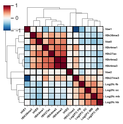

[output not shown]

13 rows × 27 columns

```python
all_vae_data = np.copy(vae_data)
vae_data = all_vae_data[:, 0:3]
vae_vis = VVis(vae_mse, u, None)
div_cmap = 'seismic'

# -----------------------------------------------------------------------------------
#                         Figure A
# -----------------------------------------------------------------------------------
vae_vis.plot_feature_correlation(df_observed, '', columns=observed_cols, show_plt=True, user_config={'cmap': 'RdBu_r'},
                                 title=f'Feature vs observed features {experiment_name}',
                             output_dir=fig_dir, save_fig=True)
```

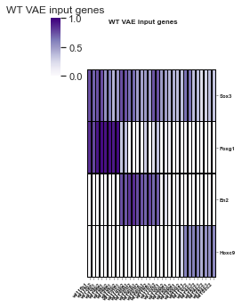

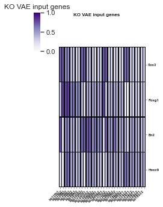

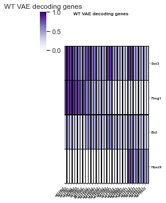

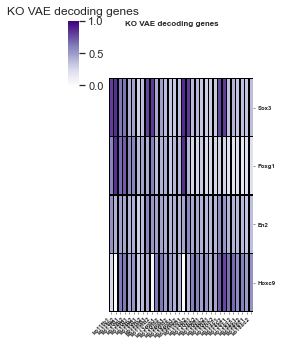

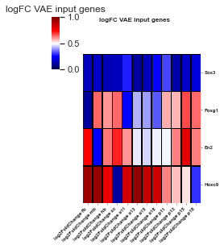

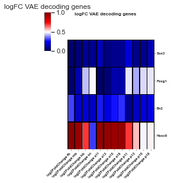

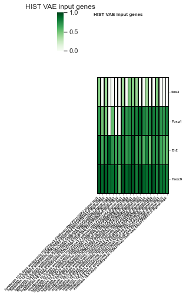

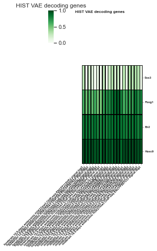

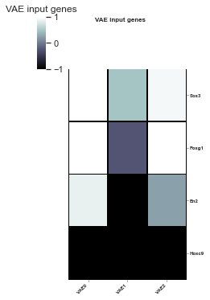

```python
# -----------------------------------------------------------------------------------
#                         Figure B
# -----------------------------------------------------------------------------------
bin_cmap = 'bone'
wt_cols = [c for c in df_input.columns if 'wt' in c]
plot_gene_heatmap(df_input, ['Sox3'], ['Foxg1'], ['En2'], ['Hoxc9'],
                  wt_cols, vae_data, vae_mse,
                  gene_name, mark='', method='input', cmap=rna_cmap, title='WT VAE input genes', v_min=0, v_max=1)
ko_cols = [c for c in df_input.columns if 'ko' in c]
plot_gene_heatmap(df_input, ['Sox3'], ['Foxg1'], ['En2'], ['Hoxc9'],
                  ko_cols, vae_data, vae_mse,
                  gene_name, mark='', method='input', cmap=rna_cmap, title='KO VAE input genes', v_min=0, v_max=1)
# Decoding of the same genes
plot_gene_heatmap(df_input, ['Sox3'], ['Foxg1'], ['En2'], ['Hoxc9'],
                  wt_cols, vae_data, vae_mse,
                  gene_name, mark='', method='decoding', cmap=rna_cmap,
                  title='WT VAE decoding genes', v_min=0, v_max=1)
plot_gene_heatmap(df_input, ['Sox3'], ['Foxg1'], ['En2'], ['Hoxc9'],
                  ko_cols, vae_data, vae_mse,
                  gene_name, mark='', method='decoding', cmap=rna_cmap,
                  title='KO VAE decoding genes', v_min=0, v_max=1)

# logFC
log_cols = [c for c in df_input.columns if 'log2FoldChange' in c]
plot_gene_heatmap(df_input, ['Sox3'], ['Foxg1'], ['En2'], ['Hoxc9'],
                  log_cols, vae_data, vae_mse,
                  gene_name, mark='', method='input', cmap=div_cmap, title='logFC VAE input genes', v_min=0, v_max=1)
# Decoding of the same genes
plot_gene_heatmap(df_input, ['Sox3'], ['Foxg1'], ['En2'], ['Hoxc9'],
                  log_cols, vae_data, vae_mse,
                  gene_name, mark='', method='decoding', cmap=div_cmap,
                  title='logFC VAE decoding genes', v_min=0, v_max=1)

# H3K27me3 cols
h3k_cols = [c for c in df_input.columns if 'H3K27me3' in c]
plot_gene_heatmap(df_input, ['Sox3'], ['Foxg1'], ['En2'], ['Hoxc9'],
                  h3k_cols, vae_data, vae_mse,
                  gene_name, mark='', method='input', cmap=hist_cmap, title='HIST VAE input genes', v_min=0, v_max=1)
# Decoding of the same genes
plot_gene_heatmap(df_input, ['Sox3'], ['Foxg1'], ['En2'], ['Hoxc9'],
                  h3k_cols, vae_data, vae_mse,
                  gene_name, mark='', method='decoding', cmap=hist_cmap,
                  title='HIST VAE decoding genes', v_min=0, v_max=1)

# latent space
plot_gene_heatmap(df, ['Sox3'], ['Foxg1'], ['En2'], ['Hoxc9'],
                  ['VAE0', 'VAE1', 'VAE2'], vae_data, vae_mse,
                  gene_name, mark='', method='input', cmap=bin_cmap, title='VAE input genes', v_min=-1, v_max=1)
```